# HW4: Autoencoders & RNNs

Paul McSlarrow

The homework is broken up as follows:

1. Question 1: Masked Autoencoder, Revisited (three points total)
2. Question 2: A Simple Sequence Task (three points total)
3. Question 3: Sequence-to-Sequence Translation (three points total)
4. Question 4: Short Response (two points total)
5. Question 5: Deep Reinforcement learning (four points total)

## Setup

If you do not have access to a CUDA-compatible NVIDIA GPU, it is recommended that you run this notebook in [Google Colab](https://colab.research.google.com/). There, you will have the option to enable GPU acceleration with `Runtime` >> `Change runtime type` >> `Hardware accelerator` >> `GPU` >> `Save`. Note that you may have to re-connect or restart the notebook after changing runtime types.

```python
# helper code from the course repository
!git clone https://github.com/interactiveaudiolab/course-deep-learning.git
# install common pacakges used for deep learning
!cd course-deep-learning/ && pip install -r requirements.txt
```

```python
%matplotlib inline
%cd course-deep-learning/

import datetime
import math
import torch
import matplotlib.pyplot as plt
import numpy as np
import IPython.display as ipd
from matplotlib.animation import FuncAnimation
from pathlib import Path
from torch.utils.tensorboard import SummaryWriter
from torchsummary import summary
from tqdm import tqdm
import torchvision

from utils.gan import *
```

```
/content/course-deep-learning
```

## Question 1: Masked Autoencoder, Revisited (3 points total)

### **1.1** A Bigger Mask (one point)

Train the MLP-based inpainting autoencoder from [notebook 7](https://github.com/interactiveaudiolab/course-deep-learning/blob/main/notebooks/notebook_7_autoencoder.ipynb) but this time, re-write `apply_mask()` (and your training code) to **deterministically zero-out the *left half* of every input image. Train for 30 epochs, and place a plot of your reconstruction loss vs. epochs below.**

*Hint: make sure that you apply the mask to a copy of each input rather than destructively editing the input itself, as the original input still has to serve as a target!*

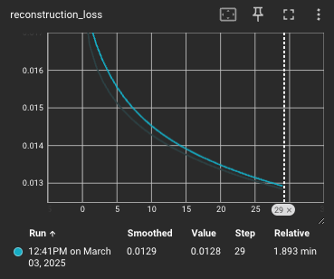

### **1.2** Reconstruction (one point)

The code below provides a hard-coded example image of a "3." **Pass this image through your new inpainting autoencoder and include the reconstructed image below. Does your autoencoder faithfully reconstruct the input (i.e. produce a similar-looking image of the same class)? If not, briefly explain why you think the reconstruction looks the way it does.**

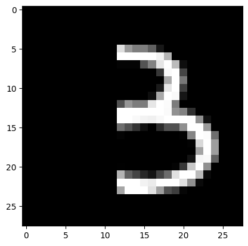

```python
x = torch.as_tensor(
    [[[0.0000, 0.0000, 0.0000, 0.0000, 0.0000, 0.0000, 0.0000, 0.0000, 0.0000, 0.0000, 0.0000, 0.0000, 0.0000, 0.0000, 0.0000, 0.0000, 0.0000, 0.0000, 0.0000, 0.0000, 0.0000, 0.0000, 0.0000, 0.0000, 0.0000, 0.0000, 0.0000, 0.0000],
      [0.0000, 0.0000, 0.0000, 0.0000, 0.0000, 0.0000, 0.0000, 0.0000, 0.0000, 0.0000, 0.0000, 0.0000, 0.0000, 0.0000, 0.0000, 0.0000, 0.0000, 0.0000, 0.0000, 0.0000, 0.0000, 0.0000, 0.0000, 0.0000, 0.0000, 0.0000, 0.0000, 0.0000],
      [0.0000, 0.0000, 0.0000, 0.0000, 0.0000, 0.0000, 0.0000, 0.0000, 0.0000, 0.0000, 0.0000, 0.0000, 0.0000, 0.0000, 0.0000, 0.0000, 0.0000, 0.0000, 0.0000, 0.0000, 0.0000, 0.0000, 0.0000, 0.0000, 0.0000, 0.0000, 0.0000, 0.0000],
      [0.0000, 0.0000, 0.0000, 0.0000, 0.0000, 0.0000, 0.0000, 0.0000, 0.0000, 0.0000, 0.0000, 0.0000, 0.0000, 0.0000, 0.0000, 0.0000, 0.0000, 0.0000, 0.0000, 0.0000, 0.0000, 0.0000, 0.0000, 0.0000, 0.0000, 0.0000, 0.0000, 0.0000],
      [0.0000, 0.0000, 0.0000, 0.0000, 0.0000, 0.0000, 0.0000, 0.0000, 0.0000, 0.0000, 0.0000, 0.0000, 0.0000, 0.0000, 0.0000, 0.0000, 0.0000, 0.0000, 0.0000, 0.0000, 0.0000, 0.0000, 0.0000, 0.0000, 0.0000, 0.0000, 0.0000, 0.0000],
      [0.0000, 0.0000, 0.0000, 0.0000, 0.0000, 0.0000, 0.0000, 0.0000, 0.0000, 0.0000, 0.0000, 0.0000, 0.8667, 0.6000, 0.4941, 0.4941, 0.3765, 0.0941, 0.0000, 0.0000, 0.0000, 0.0000, 0.0000, 0.0000, 0.0000, 0.0000, 0.0000, 0.0000],
      [0.0000, 0.0000, 0.0000, 0.0000, 0.0000, 0.0000, 0.0000, 0.0000, 0.0000, 0.0000, 0.0000, 0.0000, 0.9961, 0.9961, 0.9961, 0.9961, 0.9961, 0.9490, 0.7059, 0.0000, 0.0000, 0.0000, 0.0000, 0.0000, 0.0000, 0.0000, 0.0000, 0.0000],
      [0.0000, 0.0000, 0.0000, 0.0000, 0.0000, 0.0000, 0.0000, 0.0000, 0.0000, 0.0000, 0.0000, 0.0000, 0.0157, 0.0157, 0.0157, 0.3255, 0.5059, 0.8941, 0.9922, 0.7294, 0.0549, 0.0000, 0.0000, 0.0000, 0.0000, 0.0000, 0.0000, 0.0000],
      [0.0000, 0.0000, 0.0000, 0.0000, 0.0000, 0.0000, 0.0000, 0.0000, 0.0000, 0.0000, 0.0000, 0.0000, 0.0000, 0.0000, 0.0000, 0.0000, 0.0000, 0.2118, 0.9765, 0.9961, 0.2706, 0.0000, 0.0000, 0.0000, 0.0000, 0.0000, 0.0000, 0.0000],
      [0.0000, 0.0000, 0.0000, 0.0000, 0.0000, 0.0000, 0.0000, 0.0000, 0.0000, 0.0000, 0.0000, 0.0000, 0.0000, 0.0000, 0.0000, 0.0000, 0.0000, 0.0000, 0.6627, 0.9961, 0.4706, 0.0000, 0.0000, 0.0000, 0.0000, 0.0000, 0.0000, 0.0000],
      [0.0000, 0.0000, 0.0000, 0.0000, 0.0000, 0.0000, 0.0000, 0.0000, 0.0000, 0.0000, 0.0000, 0.0000, 0.0000, 0.0000, 0.0000, 0.0000, 0.0000, 0.1020, 0.8980, 0.9961, 0.2471, 0.0000, 0.0000, 0.0000, 0.0000, 0.0000, 0.0000, 0.0000],
      [0.0000, 0.0000, 0.0000, 0.0000, 0.0000, 0.0000, 0.0000, 0.0000, 0.0000, 0.0000, 0.0000, 0.0000, 0.0000, 0.0000, 0.0000, 0.0000, 0.0549, 0.6588, 0.9961, 0.9725, 0.0863, 0.0000, 0.0000, 0.0000, 0.0000, 0.0000, 0.0000, 0.0000],
      [0.0000, 0.0000, 0.0000, 0.0000, 0.0000, 0.0000, 0.0000, 0.0000, 0.0000, 0.0000, 0.0000, 0.0000, 0.3216, 0.5843, 0.4863, 0.4863, 0.8980, 0.9961, 0.9804, 0.4863, 0.0000, 0.0000, 0.0000, 0.0000, 0.0000, 0.0000, 0.0000, 0.0000],
      [0.0000, 0.0000, 0.0000, 0.0000, 0.0000, 0.0000, 0.0000, 0.0000, 0.0000, 0.0000, 0.0000, 0.0000, 0.9961, 0.9961, 0.9961, 0.9961, 0.9961, 0.9961, 0.9765, 0.5647, 0.5059, 0.1882, 0.0000, 0.0000, 0.0000, 0.0000, 0.0000, 0.0000],
      [0.0000, 0.0000, 0.0000, 0.0000, 0.0000, 0.0000, 0.0000, 0.0000, 0.0000, 0.0000, 0.0000, 0.0000, 0.9961, 0.9961, 0.9725, 0.9490, 0.9373, 0.9686, 0.9961, 0.9961, 0.9961, 0.9922, 0.5647, 0.0706, 0.0000, 0.0000, 0.0000, 0.0000],
      [0.0000, 0.0000, 0.0000, 0.0000, 0.0000, 0.0000, 0.0000, 0.0000, 0.0000, 0.0000, 0.0000, 0.0000, 0.4314, 0.3176, 0.2000, 0.0627, 0.0000, 0.1765, 0.3176, 0.3176, 0.5608, 0.9961, 0.9961, 0.6000, 0.0000, 0.0000, 0.0000, 0.0000],
      [0.0000, 0.0000, 0.0000, 0.0000, 0.0000, 0.0000, 0.0000, 0.0000, 0.0000, 0.0000, 0.0000, 0.0000, 0.0157, 0.0000, 0.0000, 0.0000, 0.0000, 0.0000, 0.0000, 0.0000, 0.0118, 0.5176, 0.9961, 0.9843, 0.4353, 0.0000, 0.0000, 0.0000],
      [0.0000, 0.0000, 0.0000, 0.0000, 0.0000, 0.0000, 0.0000, 0.0000, 0.0000, 0.0000, 0.0000, 0.0000, 0.0000, 0.0000, 0.0000, 0.0000, 0.0000, 0.0000, 0.0000, 0.0000, 0.0000, 0.0118, 0.8471, 0.9961, 0.6157, 0.0000, 0.0000, 0.0000],
      [0.0000, 0.0000, 0.0000, 0.0000, 0.0000, 0.0000, 0.0000, 0.0000, 0.0000, 0.0000, 0.0000, 0.0000, 0.0000, 0.0000, 0.0000, 0.0000, 0.0000, 0.0000, 0.0000, 0.0000, 0.0000, 0.0000, 0.6392, 0.9961, 0.6157, 0.0000, 0.0000, 0.0000],
      [0.0000, 0.0000, 0.0000, 0.0000, 0.0000, 0.0000, 0.0000, 0.0000, 0.0000, 0.0000, 0.0000, 0.0000, 0.0000, 0.0000, 0.0000, 0.0000, 0.0000, 0.0000, 0.0000, 0.0000, 0.0000, 0.0745, 0.9608, 0.9725, 0.3843, 0.0000, 0.0000, 0.0000],
      [0.0000, 0.0000, 0.0000, 0.0000, 0.0000, 0.0000, 0.0000, 0.0000, 0.0000, 0.0000, 0.0000, 0.0000, 0.0039, 0.0000, 0.0000, 0.0000, 0.0000, 0.0000, 0.0000, 0.0157, 0.2196, 0.7765, 0.9961, 0.5608, 0.0000, 0.0000, 0.0000, 0.0000],
      [0.0000, 0.0000, 0.0000, 0.0000, 0.0000, 0.0000, 0.0000, 0.0000, 0.0000, 0.0000, 0.0000, 0.0000, 0.6980, 0.3804, 0.2667, 0.1529, 0.0824, 0.2667, 0.4235, 0.8745, 0.9961, 0.9961, 0.7255, 0.0392, 0.0000, 0.0000, 0.0000, 0.0000],
      [0.0000, 0.0000, 0.0000, 0.0000, 0.0000, 0.0000, 0.0000, 0.0000, 0.0000, 0.0000, 0.0000, 0.0000, 0.9961, 0.9961, 0.9961, 0.9451, 0.9176, 0.9961, 0.9961, 0.9961, 0.8745, 0.5608, 0.0392, 0.0000, 0.0000, 0.0000, 0.0000, 0.0000],
      [0.0000, 0.0000, 0.0000, 0.0000, 0.0000, 0.0000, 0.0000, 0.0000, 0.0000, 0.0000, 0.0000, 0.0000, 0.6471, 0.9961, 0.9961, 0.9961, 0.8784, 0.6157, 0.3216, 0.2431, 0.0235, 0.0000, 0.0000, 0.0000, 0.0000, 0.0000, 0.0000, 0.0000],
      [0.0000, 0.0000, 0.0000, 0.0000, 0.0000, 0.0000, 0.0000, 0.0000, 0.0000, 0.0000, 0.0000, 0.0000, 0.0000, 0.0000, 0.0000, 0.0000, 0.0000, 0.0000, 0.0000, 0.0000, 0.0000, 0.0000, 0.0000, 0.0000, 0.0000, 0.0000, 0.0000, 0.0000],
      [0.0000, 0.0000, 0.0000, 0.0000, 0.0000, 0.0000, 0.0000, 0.0000, 0.0000, 0.0000, 0.0000, 0.0000, 0.0000, 0.0000, 0.0000, 0.0000, 0.0000, 0.0000, 0.0000, 0.0000, 0.0000, 0.0000, 0.0000, 0.0000, 0.0000, 0.0000, 0.0000, 0.0000],
      [0.0000, 0.0000, 0.0000, 0.0000, 0.0000, 0.0000, 0.0000, 0.0000, 0.0000, 0.0000, 0.0000, 0.0000, 0.0000, 0.0000, 0.0000, 0.0000, 0.0000, 0.0000, 0.0000, 0.0000, 0.0000, 0.0000, 0.0000, 0.0000, 0.0000, 0.0000, 0.0000, 0.0000],
      [0.0000, 0.0000, 0.0000, 0.0000, 0.0000, 0.0000, 0.0000, 0.0000, 0.0000, 0.0000, 0.0000, 0.0000, 0.0000, 0.0000, 0.0000, 0.0000, 0.0000, 0.0000, 0.0000, 0.0000, 0.0000, 0.0000, 0.0000, 0.0000, 0.0000, 0.0000, 0.0000, 0.0000]]])

plt.imshow(x.squeeze(), cmap='gray')
plt.show()
```

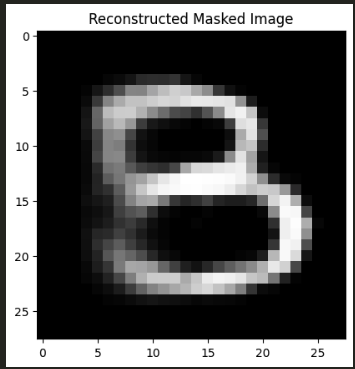

No, the autoencoder fails to reconstruct the input. I believe this is because our model was trained to reconstruct an input image from the left half of the image missing everytime. This then explains why the 8 that was constructed is slightly blurred -- there are many different numbers that have pixels on the left side that our model has to recognize to reconstruct. Now, in this specific case (as human beings too) if you asked us to reconstruct the remainder of the number based on the left half being cut off, I too would have predicted that it was either a 3 or an 8, but similar to our model, we have no true way of knowing because we only trained it on a very specific example that takes too much information away from our model to be able to generalize properly.

### **1.3** Augmentation (one point)

In [notebook 4](https://github.com/interactiveaudiolab/course-deep-learning/blob/main/notebooks/notebook_4_augmentation_logging.ipynb), we learned how to apply random augmentations to image data. **Create a `RandomAffine` transform that applies:**

- **Rotations between -10 and 10 degrees**
- **Horizontal and vertical translations of at most 0.2**
- **Shear between -5 and 5 degrees**

**Using this randomized transform, create three augmented versions of the hard-coded image above. For each augmented version obtain a reconstruction by passing it to your inpainting autoencoder. Include the three augmented images and three corresponding reconstructions below.**

**Finally, answer the following question: does your autoencoder reconstruct the augmented images correctly and consistently? If not, explain why you think this may be the case.**

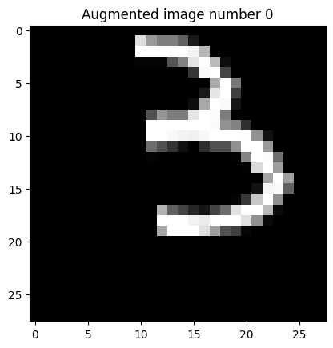

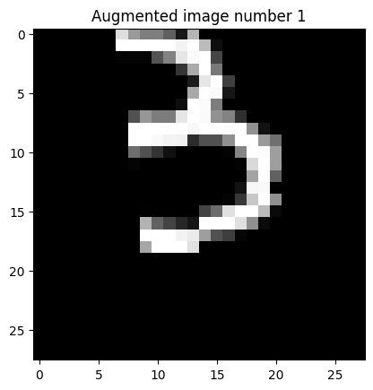

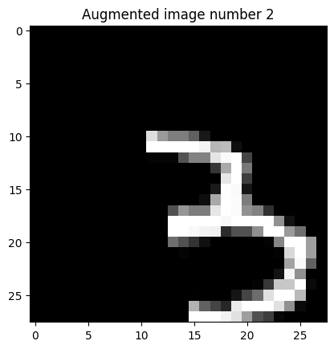

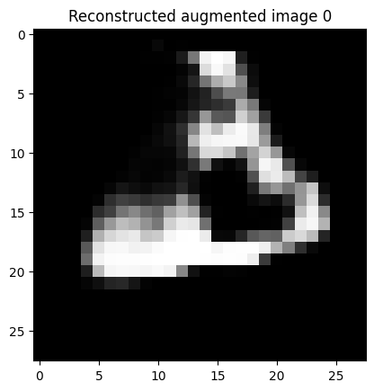

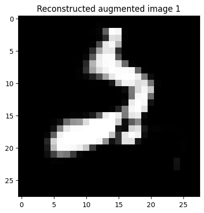

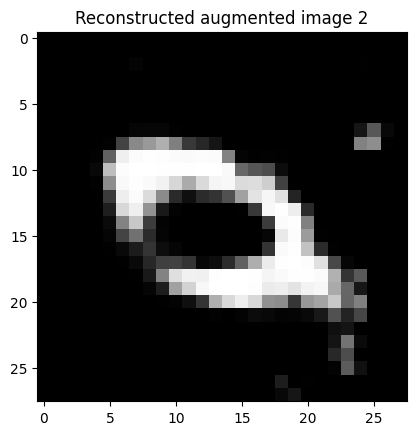

My autoencoder fails to reconstruct images correctly, but reconstructs consistently bad examples. I believe that the reason for this can be explained behind the way that we trained the model -- with there being a mask on the left half of the image. Therefore, when the model is receiving new data that is adjusted in ways that it did not learn, it still has to make predictions based on the model's internal structure. Therefore, our model is making nearly random predictions for what it thinks the data should look like, because it is not used to it.

## Question 2: A Simple Sequence Task (4 points total)

In this question, we'll explore the differences between standard recurrent neural networks (RNNs) and long short-term memory networks (LSTMs) using a simple addition task akin to the one used in the [original LSTM paper](https://www.researchgate.net/publication/13853244_Long_Short-term_Memory).

### **2.1** Theoretical Comparison (1 points)

**Explain the argument for why we would expect an [LSTM](https://www.researchgate.net/publication/13853244_Long_Short-term_Memory) to outperform a standard RNN on problems that involve processing long sequences.**

The argument for why we would expect an LSTM to outperform a standard RNN on problems with long sequences has to do with the exploding and vanishing gradients problem. In a traditional RNN, when weights are less than 1, as they increase towards the long length of the sequence in backpropogation, they will approach 0, and when the weights are greater than 1, they approach infinity. An LSTM is useful for mitigating against this problem because they use gating mechanisms to keep gradients stable by maintaining and forgetting long term information over time.

### **2.2** Empirical Comparison (2 points)

**Use the code provided below to compare the performance of a standard RNN to an LSTM on the task defined by the `Add2DigitsDataset`. Do this for three different lengths of sequence (5, 10, and 30). For all experiments, use a hidden size of 128 and 2 layers. Keep your network architecture the same, except for the substitution of the LSTM for an RNN. Provide the following graphs for each sequence length:**

1. **Loss as a function of the number of training steps**
2. **Training accuracy & validation accuracy as a function of the number of training steps.**

RNN Training Loss

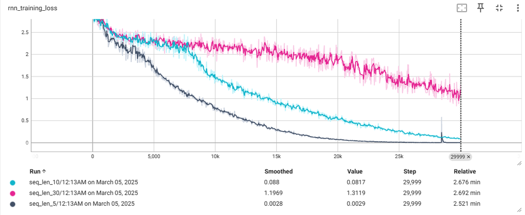

LSTM Training Loss

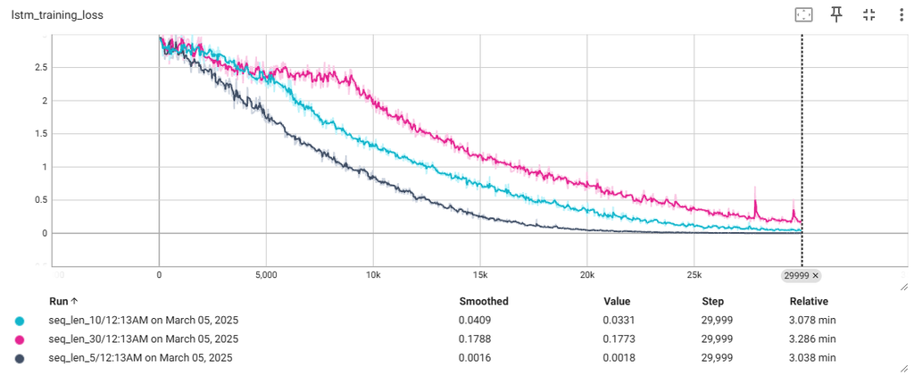

RNN Training Accuracy

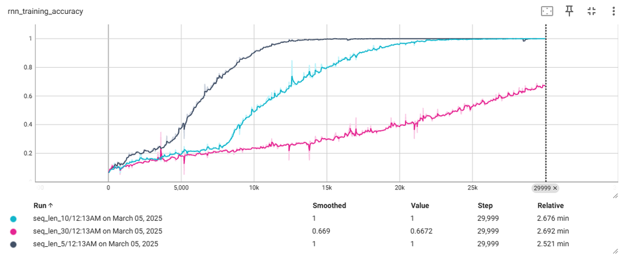

LSTM Training Accuracy

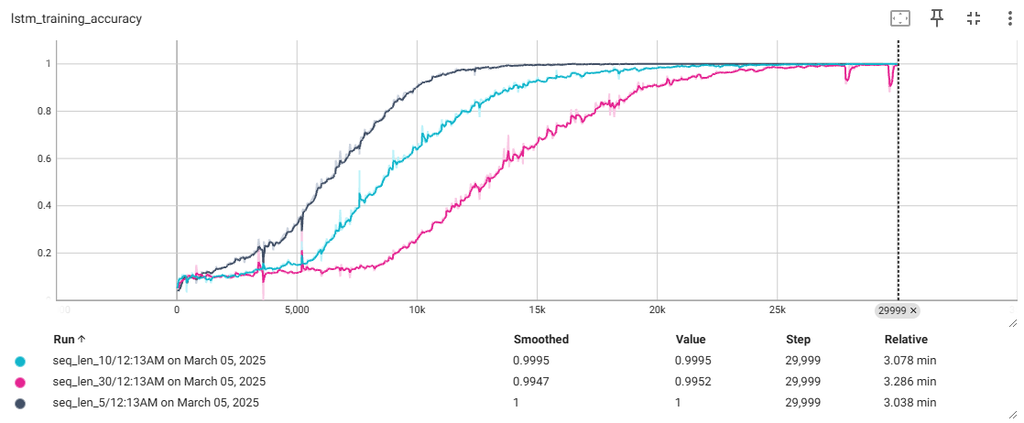

RNN Validation Accuracy

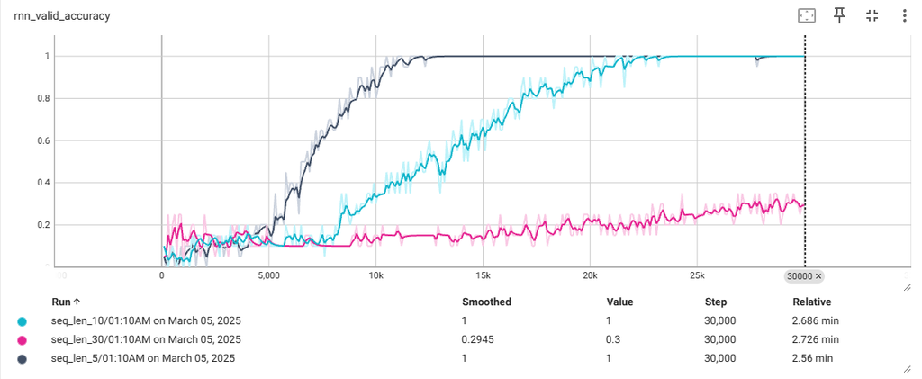

LSTM Valid Accuracy

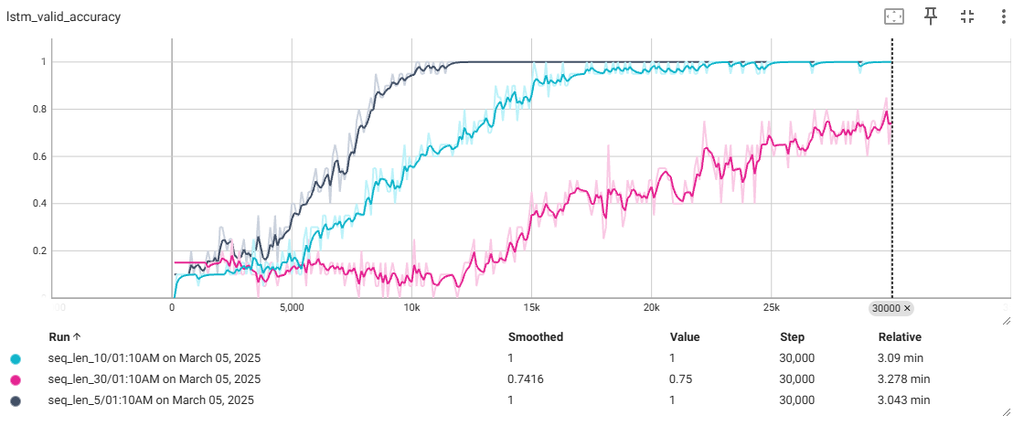

The following utility code is provided to help with the question. Note that the addition task is formulated as a *classification* rather than *regression* problem: because the operands are digits, their sum must be a positive integer in [0, 18], allowing us to output a vector of "class scores" over these potential values.

```python
!rm -rf logs/
%load_ext tensorboard
%tensorboard --logdir logs --port 6006

run_time = datetime.datetime.now().strftime("%I:%M%p on %B %d, %Y")
log_dir = 'logs'
writers = {}
sequence_lengths = [5, 10, 30]

for seq in sequence_lengths:
    writers[seq] = SummaryWriter(log_dir=Path(f"{log_dir}/seq_len_{seq}") / run_time, flush_secs=20)
```

```
The tensorboard extension is already loaded. To reload it, use:
  %reload_ext tensorboard
```

```
Reusing TensorBoard on port 6006 (pid 50475), started 0:56:46 ago. (Use '!kill 50475' to kill it.)
```

```python
def MakeItHot(data, num_tokens):
  """ Make the one hot encoding of the input."""
  i_size, j_size = data.shape
  one_hot_data = torch.zeros(i_size, j_size, num_tokens)
  for i in range(0,i_size):
    for j in range(0,j_size):
      one_hot_data[i,j,data[i,j]] = 1
  return one_hot_data

def KeepItCool(data):
  """Just use the data as-is...but with a new dimension added"""
  return torch.unsqueeze(data,2)


class Add2DigitsDataset(torch.utils.data.Dataset):
    """Add2DigitsDataset"""

    def __init__(self, num_examples=3, seq_length=10):
        """Create a set of examples, where each example is a sequence of single
        positive digits (0 through 9) interspersed with 1 instance of a negative
        one. The game is to sum the final digit in the sequence with the
        digit after the -1. The correct label y for the sequence x is the sum of
        these two digits. Here are 3 examples.

        x = [1, -1, 3, 7, 8, 9] y = 12
        x = [9, 1, 2, 4, -1, 7, 2, 3, 1, 0] y = 7
        x = [9, -1, 9, 2 , 1, 3, 0, 5, 6, 4, 7, 8, 5, 1] y = 10


        PARAMETERS
        ----------
        num_examples    A non-negative integer determining how much data we'll generate
        seq_length      A non-negative integer saying how long the sequences all are.

        EXAMPLE USE
        -----------
        dataset = Add2DigitsDataset(num_examples = 100, seq_length = 9)
        data, one_hot_data, labels  = dataset[:]
        print(f'Train instances: one_hot_data (shape {one_hot_data.shape}), labels (shape {labels.shape})')
        loader =  torch.utils.data.DataLoader(dataset, batch_size=10, shuffle=True)
        """

        assert seq_length >=3, "Seq_length must be a minimum of 3"
        self.seq_length = seq_length
        self.num_tokens = 11

        # make random sequences of integers of the right length
        data = torch.randint(10, (num_examples, seq_length))
        # the labels will go here...
        label = torch.ones(num_examples,1)

        # Now insert our special tokens
        for x in range(0, num_examples):
          # figure out where to place our special token
          a_idx = torch.randint(0, seq_length-2, (1,1)).squeeze()
          # insert the special_tokens
          data[x,[a_idx]] = -1
          # create the label by summing the digit after the special -1 token
          # with the final digit in the sequence
          label[x] = data[x,a_idx+1]+data[x,-1]

        # OK. Store data for later.
        self.data = KeepItCool(data)
        self.one_hot_data = MakeItHot(data, num_tokens=self.num_tokens)
        self.label = label.squeeze().long()
        self.lengths = self.seq_length * torch.ones_like(self.label)
        self.lengths = self.lengths.squeeze().long().tolist()

    def __len__(self):
      return len(self.label)

    def __getitem__(self, idx):
      return self.data[idx], self.one_hot_data[idx], self.label[idx] #, self.lengths[idx]



# Make sure our dataset looks correct by looking at a few examples...
# dataset = Add2DigitsDataset(num_examples=100,seq_length=sequence_length)
# data, one_hot_data, labels = dataset[:3]
# # inputs have shape (B, MAX_L, V) where MAX_L is largest length in batch
# print(f'data.shape: {data.shape}, one_hot_data.shape: {one_hot_data.shape}, labels.shape: {labels.shape}')
# print(f'data: {data}, one_hot_data: {one_hot_data}, labels: {labels}')
```

```python
class MyRNN(nn.Module):
  """ A simple RNN that that lets you select architectural features when creating
  a new instance """

  def __init__(self,
               input_size: int,
               hidden_size: int,
               output_size: int,
               num_layers: int = 1,
               use_LSTM: bool = True):

    super().__init__()

    if use_LSTM:
      self.rnn = nn.LSTM(
        input_size=input_size,
        hidden_size=hidden_size,
        num_layers=num_layers,
        batch_first=True)
    else:
      self.rnn = nn.RNN(
        input_size=input_size,
        hidden_size=hidden_size,
        num_layers=num_layers,
        batch_first=True)

    self.out_proj = nn.Linear(hidden_size, output_size)


  def forward(self, x: torch.Tensor):

    # require batched inputs: (B, MAX_L, V)
    # Here b = the batch size, l = sequence length , v = input token size (i.e.
    # the number of positiions in a one-hot-encoding array)
    assert x.ndim == 3
    b, l, v = x.shape

    # built-in PyTorch layer handles loop along sequence dimension,
    # including passing hidden state back each time step. It also
    # handles creating a new initial state for each batch!
    output, hidden = self.rnn(x)

    # for each item in batch, take final output state
    output = output[:,-1,:]

    # apply final linear layer to get predictions
    output = self.out_proj(output)

    return output


# declare the model and try out th untrained model on a sequence
```

```python
import torch
import torch.nn as nn
from tqdm import tqdm

device = torch.device('cuda' if torch.cuda.is_available() else 'cpu')

prefixes = ['rnn', 'lstm']

for prefix in prefixes:
    use_lstm = True if prefix == 'lstm' else False

    for seq in sequence_lengths:
        model = MyRNN(
            input_size=11,
            hidden_size=128,
            output_size=19,
            num_layers=2,
            use_LSTM=use_lstm
        )

        model.to(device)

        model.train()

        logger = writers[seq]
        dataset = Add2DigitsDataset(num_examples=5000, seq_length=seq)
        train_data, valid_data = torch.utils.data.random_split(dataset, [0.8, 0.2])

        train_loader = torch.utils.data.DataLoader(
            train_data,
            batch_size=20,
            shuffle=True
        )
        valid_loader = torch.utils.data.DataLoader(
            valid_data,
            batch_size=20,
            shuffle=False
        )

        loss_function = nn.CrossEntropyLoss()
        optimizer = torch.optim.Adam(model.parameters(), lr=1e-4)

        epochs = 150
        training_step = 0

        for epoch in range(epochs):

            correct = 0
            n = 0
            total_loss = 0.0

            pbar = tqdm(enumerate(train_loader), total=len(train_loader))
            for j, batch in pbar:
                optimizer.zero_grad()

                data, one_hot_data, labels = batch
                data, one_hot_data, labels = data.to(device), one_hot_data.to(device), labels.to(device)

                predictions = model(one_hot_data)

                loss = loss_function(predictions, labels)
                total_loss += loss.item()

                loss.backward()
                optimizer.step()

                training_step += 1

                pbar.set_description(f'Epoch {epoch+1}/{epochs}, Loss: {loss.item():0.4f}   Sequence Length: {seq}')

                correct += ((predictions.argmax(dim=-1) == labels) > 0).sum().item()
                n += len(labels)

                logger.add_scalar(f"{prefix}_training_loss", loss.item(), training_step)
                logger.add_scalar(f"{prefix}_training_accuracy", correct / n, training_step)

                if training_step % 100 == 0:
                    model.eval()
                    correct = 0
                    n = 0
                    with torch.no_grad():
                        val_data, val_one_hot, val_labels = next(iter(valid_loader))
                        val_data, val_one_hot, val_labels = val_data.to(device), val_one_hot.to(device), val_labels.to(device)

                        pred = model(val_one_hot)

                        correct += ((pred.argmax(dim=-1) == val_labels) > 0).sum().item()
                        n += len(val_labels)

                        accuracy = correct / n
                        logger.add_scalar(f"{prefix}_valid_accuracy", accuracy, training_step)
                    model.train()
```

## Question 3: Short Response (2 points total)

### **3.1** What is an LSTM, anyhow? (one point)

**Describe, in your own words, the differences between an LSTM, and a simple RNN. Illustrate your answer visually with a diagram or diagrams. Also feel free to use math, as long as your terms are defined. It is OK to use existing images if you cite them and describe them in your own words.**

The main difference between an LSTM and a simple RNN is in how they handle long term information. While both *can* keep information into the long term, you will notice in the pictures I have shown that the RNN does not have any gating mechanisms. Therefore, as the length of the sequence increases, the chances of our gradients vanishing or exploding also increase as well. In slightly more detail, within the RNN, we conduct out linear transofmration followed by an activation function and then use this hidden state as the hidden input for the next state. This way each state in the sequence can contain information from the past (only the past here because it is not bidirectional). Within the LSTM, however, we introduce the forget, input, cell state, and output gate. The forget gate decides what information to discard from the previous cell, the input gate decides what new information should be added to the state, the cell state combines the old state and the new candidate, and the output gate determines the next hidden state to pass on. This way, as the size of the sequence may increase, an LSTM is able to almost dynamically adjust what information it is remembering and forgetting from the past. In case you also want me to describe this diagram, if we take our attention to the LSTM diagram, we notice that there are two memorie -- short term memory and long term memory. We also see (in action) the sum between the previous hiddden state (output of the previous layer) and the new input, as well as the updating of the long term information with the multiplication and addition between the previous long term and the potential new long term memory. The RNN just continuosly updates the new state based on hidden states and considers a single moment in time to hold long term and short term memory, whereas the LSTM has these separated.

Source(s): https://lightning.ai/lightning-ai/studios/statquest-long-short-term-memory-lstm-with-pytorch-lightning?section=featured and https://www.youtube.com/watch?v=YCzL96nL7j0 and https://www.youtube.com/watch?v=AsNTP8Kwu80

RNN Image

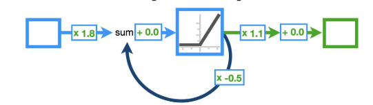

LSTM Image

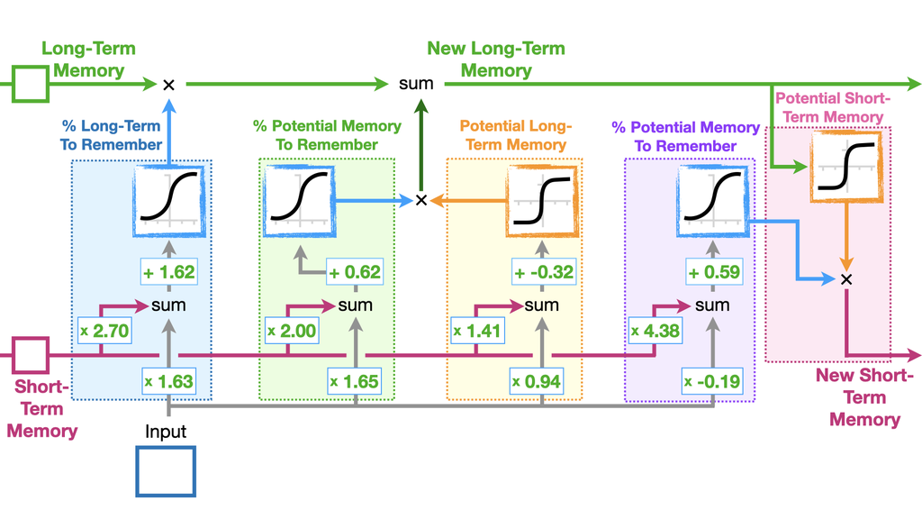

### **3.2** GRUs vs LSTMs (one point)

Gated recurrent units (GRUs) and long short-term memory (LSTMs) are both types of recurrent neural networks (RNNs) that use gating mechanisms to control memory. Go out on the web and do some research and then do the following.

**Describe, in your own words, the difference between a GRU and an LSTM. Give an example of a problem or a situation where you would be better off using a GRU and one where you would be better off using an LSTM. Explain your reasoning. Cite and quote a passage in the relevant article(s) that back up your assertion.**

The difference between a GRU and an LSTM is within the way that the gate architectures are built. In a LSTM, we have a short term memory and a long term memory, and the memory cell is updated with three gates (input, output, and forget). In a GRU, there are only two gates (reset, update) that update a "candidate activation vector" which learns and forgets information to pass between cells. The article also noted that the GRU has "fewer parameters, which can make it easier to train and more computationally efficient". The GRU is able to update its own hidden state to pass along "without the need for a separate memory cell state like in LSTM". Therefore, a situation where we may be better off using a GRU than an LSTM, would be any problem that we need to be less computationally expensive and that might require fewer model parameters. Think could range from a super simplified natural language task with fewer tokens and short sequences, or something in time series analysis that only relies on a relatively small amount of time.

[Article link](https://medium.com/@anishnama20/understanding-gated-recurrent-unit-gru-in-deep-learning-2e54923f3e2)

## Question 4: Short Response (2 points total)

### **4.1** State Initialization (one point)

Assume we are given the task from [notebook 8](https://github.com/interactiveaudiolab/course-deep-learning/blob/main/notebooks/notebook_8_rnn.ipynb), in which we must predict the language from which a given name originates. Assume we are training an RNN in "cell" configuration, meaning we must manually handle the propagation of states, and that we pass our network one training example at a time. Finally, recall that in notebook 8, we demonstrate how to re-initialize the RNN cell's hidden state with a zero vector.

**What kind of information does the RNN cell's hidden state hold *after* processing a full name input (but before re-initializing)?**

The hidden state of an RNN cell after processing a full name of input holds a latent representation of the full name sequence. While the last cell only holds the last word in the full name, the context that is held within the hidden representation is a new representation of the data that was originally passed in. This means that the network likely picked up on lower level details about the words that were passed in and how they connect to one another. Especially for a task like predicting the origin of a name, the final hidden representation of the word before re-initializing or before a softmax, likely holds information relating to what it means for a model to correctly predict the origin (this could be specifc letters used, the length of names, the number of words in a name, etc...).

**Assume that we do not re-initialize the RNN cell's hidden state after processing a name input. What does this mean for the hidden state when we start processing the next name input?**

If we do not re-initialize the RNN cell's hidden state after processing a name input, this would mean that the next name that is processed would hold information regarding a name that may not be directly correlated to its own origin. For example, if the first name that was processed was "Paul McSlarrow" --> English, then this would be expressed from my final hidden state. If this hidden state is then also used for "Leonardo da vinci" --> Italian, then it would carry over information that is still dependdant on Paul McSlarrow but actually has nothing to do with Da Vinci. This would likely negatively impact the model's ability to accurately predict ones origin based on the name, because names that should be independant from one another, aren't.

**Based on your answers above, when does it make most sense to re-initialize the hidden state for our task?**

1. **Only once, at the beginning of training**
2. **After processing each individual name input**
3. **After processing each epoch (i.e. after iterating over all names once)**

**Include a brief explanation supporting your answer.**

We should re-initialize the hidden state **after processing each individual name input** -- which supports my answer above. The more in depth reasoning behind this is explained directly above.

### **4.2** Network Size (one point)

Assume we are given a simplified version of our task from notebook 8, in which we must predict the language from which a given name originates. In this simplified task, names are at most 10 characters long, and characters are drawn only from the standard english alphabet (26 possibilities). Names are drawn from the same 18 languages. Assume all inputs are one-hot encoded.

We consider two different network architectures:

- Network A pads all inputs to the maximum sequence length, flattens them, and passes them through two fully connected layers with sizes 256 and 18, respectively.
- Network B is a recurrent neural network identical to `RNNCell` in notebook 8, with hidden size 256 and output size 18.

**How many parameters does each network contain? Explain your reasoning.**

In class we ignore biases for simplicity, so I feel it is safe to say I should assume the same here.

### Variables

```
Input size = 26.  Hidden Size = 256.  Output size = 18. Flattened = 260
```

### Network A

```
Total Network A = ((input * hidden) + (hidden * output))
Total Network A = ((260 * 256) + (256 * 18))
Total Network A Parameters = 71168
```

### Network B

```
Total Network B = ((input_size + hidden_size) * hidden_size) + ((input_size + hidden_size) * output_size)
Total Network B = ((26 + 256) * 256) + ((26 + 256) * 18)
Total Network B Parameters = 77268
```

**What if the maximum input length is 20 characters? What does your answer say about the sizes of fully-connected and recurrent networks as the sequence length grows?**

In class we ignore biases for simplicity, so I feel it is safe to say I should assume the same here.

### Variables

```
Input size = 26.  Hidden Size = 256.  Output size = 18. Flattened = 520
```

### Network A

```
Total Network A = ((input * hidden) + (hidden * output))
Total Network A = ((520 * 256) + (256 * 18))
Total Network A Parameters = 137728
```

### Network B

```
Total Network B = ((input_size + hidden_size) * hidden_size) + ((input_size + hidden_size) * output_size)
Total Network B = ((26 + 256) * 256) + ((26 + 256) * 18)
Total Network B Parameters = 77268
```

### What this tells us:

This example tells us that fully connected neural networks are adjusted based on the size of the sequence length. Whereas an RNN is not.

## Question 5: Reinforcement Learning (4 points total)

### **5.1** "Deep Reinforcement Learning: Pong from Pixels" (one point)

In his blog post ["Deep Reinforcement Learning: Pong from Pixels,"](http://karpathy.github.io/2016/05/31/rl/) Andrej Karpathy explains how to use Deep Reinforcement Learning (RL) to train an agent to play the game of Pong using only raw pixel input. The post provides an introduction to key concepts and techniques in RL, such as policy gradients, stochastic policies, and reward discounting. Karpathy also discusses the limitations of the policy gradient approach compared to human learning and how policy gradients can be used to train neural networks with non-differentiable components.

Please answer the following questions based on the blog post:

1. What are some limitations of the policy gradient approach compared to how humans learn? (0.5 points)
2. How can policy gradients be used to train neural networks with non-differentiable components? (0.5 points)
1. The blog post argues the policy gradient approach is limited to learning based only when it receives a positive reward (far in the future when you either win or loss in this example). While the polciy gradient approach works, humans tend to learn what to do without ever actually experiencing the rewarding or unrewarding transition. Humans have a huge amount of prior knowledge coming into playing a game and trying to succeed at that game, whereas, the way a computer learns from policy gradients is brute force, and will eventually in the long-term be able to internalize what they learn into a policy.
2. I believe that the blog post mentions that policy gradients can be used to train neural networks with non-differentiable components because making a policy decision can be thought of as a sampling method (stochastic policy) -- which is non-differentiable. So to be able to actually update these components, the policy gradient method "update[s] independently of the backward pass" to encourage samples that led to lower levels of loss. So in places where we drew from a sampling distribution, we can update our parameters independently by using a score function gradient estimator, which outputs a scalar value that estimates the reward from making a certain decision.

### **5.2** Pong (one point)

The following provides a partially completed implementation for training an agent to play Pong in [Gymnasium](https://gymnasium.farama.org/index.html) using policy gradients, as described in Andrej Karpathy's blog post ["Deep Reinforcement Learning: Pong from Pixels"](http://karpathy.github.io/2016/05/31/rl/). Your task is to complete the code. The following steps are missing:

- Implement the policy gradient backward pass in the policy_backward function.
- In the main training loop, modulate the gradient with the advantage and accumulate the gradients over the batch.
- Also in the main training loop, perform the parameter update based on the accumulated gradients every batch_size episodes.

What you need to do this can be found in the blog post. The places in the code that you need to implement something are indicated by "YOUR CODE STARTS HERE"

Some tips:

- Make sure to follow the PyTorch conventions for computing gradients and updating parameters
- Print out the running reward periodically during training to monitor progress
- If training is slow on CPU, consider using Google Colab to train with GPU acceleration (using a T4 in Colab roughly triples the speed, compared to a CPU Colab instance)
- Although this code does checkpoint to disk, if you use Colab and your runtime is reset, you may lose the checkpoint. Consider mounting a Google Drive instance and saving the checkpoint to there.

```python
#install libraries
!pip install torch numpy tqdm

# this is to install all the old atari games (including pong) from Gymnasium
!pip install gymnasium[atari,accept-rom-license]

# these are so we can render the video of the pong game
!pip install shimmy pyvirtualdisplay moviepy
!apt-get install -y xvfb ffmpeg
```

The following code shows Gymnasium in action. It generates a video of a pong game where our player acts randomly to move the paddle up and down. Look in your directory for the movie produced. If you're in Colab, look in the "video" directory and download the video you find there to view it. VLC will let you view it on PC. (VLC is a free and open-source video player. You can download it from this link: https://www.videolan.org/.) You can just click on it if you're on a Mac.

```python
""" Example Gymnasium code to run pong with a randomly-acting player and save the
    output to an .mp4 file"""
import os
import torch
import numpy as np
import gymnasium as gym
from gymnasium.wrappers import RecordVideo
from pyvirtualdisplay import Display
import subprocess
import logging
import ale_py

logging.getLogger("gymnasium").setLevel(logging.ERROR)

display = Display(visible=0, size=(1400, 900))
display.start()

# Find the latest video increment
video_dir = "./video"
os.makedirs(video_dir, exist_ok=True)
video_files = [f for f in os.listdir(video_dir) if f.startswith("rl_video_random_agent_")]
latest_increment = max([int(f.split("_")[-1].split(".")[0]) for f in video_files]) if video_files else 0

# Create the environment with the latest video increment
env = gym.make("ALE/Pong-v5", render_mode="rgb_array")
env = RecordVideo(env, video_dir, episode_trigger=lambda x: True, name_prefix=f"rl_video_random_agent_{latest_increment+1}")
observation, info = env.reset()

while True:
    env.render()

    # get the action from the player. This is what we'll be replacing with the
    # output of our trained policy network.
    aprob = 0.5
    action = 2 if torch.rand(1) < aprob else 3  # roll the dice!

    # step the environment and get new measurements
    observation, reward, terminated, truncated, info = env.step(action)

    if terminated or truncated:  # an episode finished
        break

env.close()
```

The following code is a lightly-altered version of Andrej Karpathy's original code. We've modified it to run properly in Gymnasium. Note that it hand-codes things we we would normally call as pytorch functions (e.g. ReLu and Sigmoid activations), so the network won't look like you're used to.

Note: This code uses Gymnasium, but will NOT render a movie. You use this strictly for training. Once you've trained it and gotten a saved model in 'save.pt', go on to the next question, where there is code to run your saved model and render the output to a video.

Note: Actually, train it for a few episodes (not 8000 episodes, but rather, right after your first saved checkpoint) and then hit "break" and go try generating a video with the model that you've saved. That will get you 1/3 of the points on that problem and also ensure you understand the whole work flow.

IMPORTANT! Please note that I followed the instructions and the instructions were clear that the code was in the blog. I read the blog and found this exact code block for the answers to train it. I am unsure if this is what you meant by finding the code in the blog, but I just wanted to clarify in case this is not what I was supposed to do. Thank you.

```python
""" Trains an agent with (stochastic) Policy Gradients on Pong. Uses Gymnasium. """
import torch
import torch.nn as nn
import numpy as np
import gymnasium as gym
import tqdm
from tqdm.notebook import tqdm
# from google.colab import drive
# drive.mount('/content/drive')

# hyperparameters
H = 200  # number of hidden layer neurons
batch_size = 10  # every how many episodes to do a param update?
learning_rate = 1e-3
gamma = 0.99  # discount factor for reward
decay_rate = 0.99  # decay factor for RMSProp leaky sum of grad^2
resume = False # resume from previous checkpoint?
render = False

# model initialization
D = 80 * 80  # input dimensionality: 80x80 grid

# device = torch.device("cpu")
# Uncomment the following line if you decide to make a cuda implementation
device = torch.device("cuda" if torch.cuda.is_available() else "cpu")

# This is where we load our model from a checkpoint...or else initialize from scratch.
# Note, if you don't have a 'save.pt' in your directory, you will get an error if you
# try and resume from it.  One more warning: In co-lab, when you reset your environment,
# you may lose your save.pt file. Consider saving to and reloading from
# google drive, so you don't lose intermediate work.
if resume:
    model = torch.load('/content/drive/MyDrive/save.pt')
else:
    model = {}
    model['W1'] = torch.randn(H, D, device=device) / np.sqrt(D)  # "Xavier" initialization
    model['W2'] = torch.randn(H, device=device) / np.sqrt(H)

grad_buffer = {k: torch.zeros_like(v, device=device) for k, v in model.items()}  # update buffers that add up gradients over a batch
rmsprop_cache = {k: torch.zeros_like(v, device=device) for k, v in model.items()}  # rmsprop memory

def sigmoid(x):
    return 1.0 / (1.0 + torch.exp(-x))  # sigmoid "squashing" function to interval [0,1]

def prepro(I):
    """ prepro 210x160x3 uint8 frame into 6400 (80x80) 1D float vector """
    I = I[35:195]  # crop
    I = I[::2, ::2, 0]  # downsample by factor of 2
    I[I == 144] = 0  # erase background (background type 1)
    I[I == 109] = 0  # erase background (background type 2)
    I[I != 0] = 1  # everything else (paddles, ball) just set to 1
    return torch.from_numpy(I.astype(np.float32).ravel()).to(device)

def discount_rewards(r):
    """ take 1D float array of rewards and compute discounted reward """
    discounted_r = torch.zeros_like(r)
    running_add = 0
    for t in reversed(range(r.size(0))):
        if r[t] != 0:
            running_add = 0  # reset the sum, since this was a game boundary (pong specific!)
        running_add = running_add * gamma + r[t]
        discounted_r[t] = running_add
    return discounted_r

def policy_forward(x):
    h = torch.matmul(model['W1'], x)
    h[h < 0] = 0  # ReLU nonlinearity
    logp = torch.matmul(model['W2'], h)
    p = sigmoid(logp)
    return p, h  # return probability of taking action 2, and hidden state

def policy_backward(eph, epdlogp):
    """ backward pass. (eph is array of intermediate hidden states) """
    ###########################################################
    # YOUR CODE STARTS HERE (1/3)
    ###########################################################

    # Implement the policy gradient backward pass
    dW2 = torch.matmul(eph.T, epdlogp).ravel()
    dh = torch.matmul(epdlogp.unsqueeze(1), model['W2'].unsqueeze(0))
    dh[eph <= 0] = 0 # backpro prelu
    dW1 = torch.matmul(dh.T, epx)
    return {'W1':dW1, 'W2':dW2}

    ###########################################################
    # YOUR CODE ENDS HERE (1/3)
    ###########################################################

env = gym.make("ALE/Pong-v5")
observation, info = env.reset()
prev_x = None  # used in computing the difference frame
xs, hs, dlogps, drs = [], [], [], []
running_reward = None
reward_sum = 0
episode_number = 0

pbar = tqdm()
while True:
    if episode_number > 100:
        # print("22004 currently")
        print("Watched 100")
        break

    if render:
        env.render()

    # preprocess the observation, set input to network to be difference image
    cur_x = prepro(observation)
    x = cur_x - prev_x if prev_x is not None else torch.zeros(D, device=device)
    prev_x = cur_x

    # forward the policy network and sample an action from the returned probability
    aprob, h = policy_forward(x)
    action = 2 if torch.rand(1, device=device) < aprob else 3  # roll the dice!

    # record various intermediates (needed later for backprop)
    xs.append(x)  # observation
    hs.append(h)  # hidden state
    y = 1 if action == 2 else 0  # a "fake label"
    dlogps.append(y - aprob)  # grad that encourages the action that was taken to be taken (see ;' if confused)

    # step the environment and get new measurements
    observation, reward, done, truncated, info = env.step(action)
    reward_sum += reward

    drs.append(reward)  # record reward (has to be done after we call step() to get reward for previous action)

    if done or truncated:  # an episode finished
        episode_number += 1
        pbar.update(episode_number)

        # stack together all inputs, hidden states, action gradients, and rewards for this episode
        epx = torch.stack(xs).to(device)
        eph = torch.stack(hs).to(device)
        epdlogp = torch.stack(dlogps).to(device)
        epr = torch.tensor(drs, device=device)
        xs, hs, dlogps, drs = [], [], [], []  # reset array memory

        # compute the discounted reward backwards through time
        discounted_epr = discount_rewards(epr)
        # standardize the rewards to be unit normal (helps control the gradient estimator variance)
        discounted_epr -= discounted_epr.mean()
        discounted_epr /= discounted_epr.std()


        ###########################################################
        # YOUR CODE STARTS HERE (2/3)
        ###########################################################

        # modulate the gradient with advantage (PG magic happens right here.)
        # it might be good to do something with policy_backward
        # accumulate grad over batch

        # If our advantage function is the discounted_epr, then our policy gradient
        # is just discounted_epr * log probability.

        epdlogp *= discounted_epr # modulate the gradient with advantage (PG magic happens right here.)
        grad = policy_backward(eph, epdlogp)
        for k in model: grad_buffer[k] += grad[k]


        ###########################################################
        # YOUR CODE ENDS HERE (2/3)
        ###########################################################


        # perform rmsprop parameter update every batch_size episodes
        if episode_number % batch_size == 0:

            ###########################################################
            # YOUR CODE STARTS HERE (3/3)
            ###########################################################
            # If it were me, I'd loop through k and v in the model items
            #   For every element k of grad_buffer, I'd get the gradient
            #   Then, for the kth rmsprop_cache element I'd do my update
            #   Then I'd update the model's kth item appropriately
            #   Then I'd reset the grad_buffer to zeros.
            # Look at the blog code for more....
            for k,v in model.items():
                g = grad_buffer[k] # gradient
                rmsprop_cache[k] = decay_rate * rmsprop_cache[k] + (1 - decay_rate) * g**2
                model[k] += learning_rate * g / (torch.sqrt(rmsprop_cache[k]) + 1e-5)
                grad_buffer[k] = torch.zeros_like(v) # reset batch gradient buffer

            ###########################################################
            # YOUR CODE ENDS HERE (3/3)
            ###########################################################

        # checkpoints are saved every 100 episodes
        if episode_number % 100 == 0:
            torch.save(model, '/content/drive/MyDrive/save_100.pt')
            # boring book-keeping
            running_reward = reward_sum if running_reward is None else running_reward * 0.99 + reward_sum * 0.01
            print(f'Model saved. resetting environment. episode reward total: {reward_sum:.2f}. Running mean: {running_reward:.2f}')


        reward_sum = 0
        observation, info = env.reset()  # reset env
        prev_x = None

    if reward != 0: # Pong has either +1 or -1 reward exactly when game ends.
        pbar.set_description(f'episode {episode_number}: game finished, reward: {reward}' + ('' if reward == -1 else ' !!!!!!!!'))
```

### **5.3** Running Pong (one point)

Create 3 videos using the following code:

- A video of the agent playing pong after 100 eposodes of training
- A video of the agent playing pong after 8000 episodes of training
- A video of the agent playing after however many episodes it takes you to do about as well as [Karpathy's example video](https://www.youtube.com/watch?v=YOW8m2YGtRg&list=TLGG2Hi1VyMnZ7gxNzA1MjAyNA) of his agent (which supposedly took 8000 episodes to train).

NOTE: The code will run the model in 'save.pt' found in the current directory.

NOTE: If there is already a video in the directory with the same name, this code breaks. So, to make a 2nd video...either move your previous video elsewhere or modify the code.

[100 Episodes Link](https://drive.google.com/file/d/14yplihxcwfUrbTVX-QOMe1JyP7m2tyyc/view?usp=sharing)

[8000 Episodes Link](https://drive.google.com/file/d/1GQ9i8cpQz1do28iDe9EE95bnZJ8SqdI6/view?usp=sharing)

[22000 Episodes Link](https://drive.google.com/file/d/1EpHZyBeiMvtOGoJHmiweXyDEKt-G_v3o/view?usp=sharing)

```python
""" Useful Script to help record videos of your model playing Pong. REMEMBER TO USE VLC WHEN WATCHING!!!!!!"""

import os
import torch
import numpy as np
import gymnasium as gym
from gymnasium.wrappers import RecordVideo
from pyvirtualdisplay import Display
import subprocess
from google.colab import drive
drive.mount('/content/drive')

logging.getLogger("gymnasium").setLevel(logging.ERROR)


display = Display(visible=0, size=(1400, 900))
display.start()

# hyperparameters
D = 80 * 80  # input dimensionality: 80x80 grid
device = torch.device("cuda" if torch.cuda.is_available() else "cpu")

# load the trained model
model = torch.load('/content/drive/MyDrive/save_100.pt')

def sigmoid(x):
    return 1.0 / (1.0 + torch.exp(-x))  # sigmoid "squashing" function to interval [0,1]

def prepro(I):
    """ prepro 210x160x3 uint8 frame into 6400 (80x80) 1D float vector """
    I = I[35:195]  # crop
    I = I[::2, ::2, 0]  # downsample by factor of 2
    I[I == 144] = 0  # erase background (background type 1)
    I[I == 109] = 0  # erase background (background type 2)
    I[I != 0] = 1  # everything else (paddles, ball) just set to 1
    return torch.from_numpy(I.astype(np.float32).ravel()).to(device)

def policy_forward(x):
    h = torch.matmul(model['W1'], x)
    h[h < 0] = 0  # ReLU nonlinearity
    logp = torch.matmul(model['W2'], h)
    p = sigmoid(logp)
    return p, h  # return probability of taking action 2, and hidden state

# Find the latest video increment
video_dir = "./video"
os.makedirs(video_dir, exist_ok=True)
video_files = [f for f in os.listdir(video_dir) if f.startswith("rl_video_trained_model_")]
latest_increment = max([int(f.split("_")[-1].split(".")[0]) for f in video_files]) if video_files else 0

# Create the environment with the latest video increment
env = gym.make("ALE/Pong-v5", render_mode="rgb_array")
env = RecordVideo(env, video_dir, episode_trigger=lambda x: True, name_prefix=f"rl_video_trained_model_{latest_increment+1}")
observation, info = env.reset()
prev_x = None  # used in computing the difference frame

while True:
    env.render()

    # preprocess the observation, set input to network to be difference image
    cur_x = prepro(observation)
    x = cur_x - prev_x if prev_x is not None else torch.zeros(D, device=device)
    prev_x = cur_x

    # forward the policy network and sample an action from the returned probability
    aprob, h = policy_forward(x)
    action = 2 if torch.rand(1, device=device) < aprob else 3  # roll the dice!

    # step the environment and get new measurements
    observation, reward, terminated, truncated, info = env.step(action)

    if terminated or truncated:  # an episode finished
        break

env.close()
```

### **5.4** Understanding Deep Reinforcement Learning (one point)

Consider this code block from the main training loop for reinforcement learning in the provided code:

```
    # preprocess the observation, set input to network to be difference image
    cur_x = prepro(observation)
    x = cur_x - prev_x if prev_x is not None else torch.zeros(D, device=device)
    prev_x = cur_x
```

1. Explain the point of the preprocessing done in the function called in the first line.
2. Explain the point of subtraction of the previous frame from the current frame shown in the second line of the code. Why not just look at the current observation?
1. Our prepro() function crops, downsamples, erases the background, and intensifies the paddles and the ball. This is essential because it removes the focus on things that are not as important to the decision making process of our agent (like the background color). Furthermore, our agent's decisions are largely determined by the location of the paddles and the ball, as well as influenced by the motion from one frame to another (next question) to help make the correct decision in order to win more games.
2. Karpathy makes it clear in his reading that by subtracting the previous frame from the current frame (difference frames), it allows the model to focus on the movement of the ball more than less important fixations like the background: "Notice that several neurons are tuned to particular traces of bouncing ball...neurons are multitasking and will “fire” for multiple locations of the ball along that line". If we just look at the current observation, the model might just fixate on static information, rather than trying to learn what to do when similar motions occur within the state of the game.